# U.S. Census TIGER files

Dataset of the Week (Week 1)

# Background

The United States Census Bureau maintains and publishes geographic data on the United States and its territories. These data are published as TIGER files. TIGER stands for **T**opologically **I**ntegrated **G**eographic **E**ncoding and **R**eferencing.

You can read the Census Bureau’s description of its mission, authority, and activities here: https://www.census.gov/about/what.html.

They describe their mission as “to serve as the nation’s leading provider of quality data about its people and economy.”

The Census Bureau uses TIGER files to create maps and to collect and summarize data about the people and economy of the United States.

# Available data

Geographic areas will be polygons. Features may be points, lines, or polygons. Two useful variables that will be included with any TIGER polygon layer are `ALAND` and `WATER`, which represent the land and water areas of the polygon respectively, in square meters (this can be useful when you want to calculate a population density based on the land area rather than on the total area of a region).

## Geographic areas

Geographic areas are areas for which the Census Bureau publishes demographic data. They may be nested or non-nested.

### Nested geographies

Many national statistical agencies, including the United States Census Bureau, use nested geographies for tabulating population and demographic data. The nested geographies the United States Census Bureau uses include:

- States (and state equivalents)
- Counties (and county equivalents)
- Census tracts
- Census block groups
- Census blocks

We describe these as nested because the smaller geographies nest within larger geographies. Census block groups comprise a set of census blocks; census tracts comprise a set of census block groups; counties comprise a set of census tracts; and so on.

Census geographic areas can be identified by a numeric identifier called a GEOID (geographic identifier) or FIPS (Federal Information Processing System) code. These codes are nested as well. The FIPS code for a *census block* is a 15 digit-code. The first 12 digits of the code are FIPS the FIPS code for the *block group* the block is in. The first 11 digits of the block group FIPS code are the FIPS code for the *tract*. Figure 1 illustrates the structure of FIPS code for nested census geographies.

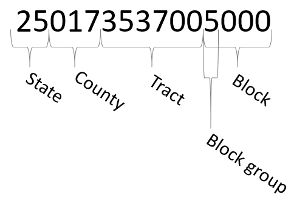

Figure 1: FIPS code for nested census geographies

**States (and state equivalents)** include 50 states, five territories, and the District of Columbia. State boundaries are political boundaries and they were drawn for political and historical reasons. State boundaries are quite stable over time.

Each state is divided into one or more **counties (or county equivalents)**. The District of Columbia and Guam each have one county equivalent. Texas has 254 counties. Like state boundaries, county boundaries were generally drawn for political and historical reasons. They may change occasionally, and these changes are more common than changes to state boundaries.[^1]

Counties are divided into **census tracts**. Census tracts are not political boundaries. The Census Bureau established census tract boundaries based on established criteria, including (among other considerations) a goal of maintaining a similar population size in each tract.[^2] Tract boundaries can change as often as every ten years.

Census tracts are divided into **census block groups**. Block group boundaries are likewise drawn by the Census Bureau based on established criteria[^3] and may change as often as every ten years.

Census block groups are sets of adjacent **census blocks**. Census blocks are bounded by physical features such as roads (most commonly), rivers, or coastlines.

### Non-nested geographies

Other census geographies are not nested, including:

- Places (including cities)
- Urbanized areas
- Core-based statistical areas
- Public-use microdata areas

FIPS codes for non-nested census geographies are assigned alphabetically.

Most cities and towns in the United states are classified as **places**. This a category that includes both legally-incorporated places (e.g. cities and towns) and unincorporated places that are equivalent to incorporated places and have a locally-used name, but do not have an functioning government.[^4] Many locations in the United States are not classified as being part of any incorporated or unincorporated place. About 24 percent of land area of Massachusetts belongs to incorporated or unincorporated places. In California, less than ten percent of all land is part of an incorporated or unincorporated place.

The places TIGER file inclused a variable `LSAD` that differentiates among types of places, including the following categories:

- City (LSAD = 25)
- Township (LSAD = 35)
- Town (LSAD = 43)
- Village (LSAD = 47)
- Census-designated place (unincorporated) (LSAD = 57)

An **Urban area** is group of contiguous census blocks that have a population density above an established threshold, irrespective of municipal or county boundaries.[^5]

**Core-based statistical areas (CBSAs)** are groups of *counties* that share economic ties, which are primarily determined based on identified commuting patterns.[^6] Many counties in the United States are not part of any core-based statistical area.

A core-based statistical area may be either a **metropolitan statistical area (MSA)** or a **micropolitan statistical area ($\mu$SA)**. An MSA is a group of connected counties containing at least one urban area with a population of at least 50,000 people. A $\mu$SA us a group of connected counties that are not in an MSA but contain at least one urban area with a population of at least 10,000 people. The CBSA TIGER file differentiates between MSAs and $\mu$SA with a variable called `LSAD`, which takes a value of `M1` for MSAs and `M2` for $\mu$SAs. There are 392 MSAs in the United States and 547 $\mu$SAs.

A **public-use microdata area (PUMA)** is a set of contiguous census tracts within a single state that have a combined population of at least 100,000 people. Each census tract in the United States is classified into one (and only one) PUMA. To protect privacy, individual- and household-level data from the United States census are not available with any geographic identifiers for areas smaller than a PUMA.

## Features

Features may be represented on a census map for context, and may define the boundaries of geographic areas. They include:

- Roads
- Rails
- Water
- Coastline
- Landmarks

Features will have an MTFCC (MAP/TIGER Feature Class Code) to classify each feature in the layer as one of several types. This document includes definitions of all current MTFCCs: https://www2.census.gov/geo/pdfs/reference/mtfccs2022.pdf

### Roads

Roads represent the roadway centerline with MTFCC codes to differentiate among categories including:

- Primary Road (S1100)
- Secondary Road (S1200)
- Local neighborhood Road, Rural Road, City Street (S1400)
- Walkway/Pedestrian Trail (S1710)

A file with only primary roads is available as a single national file. Files with only primary and secondary roads are available at the state level. Files including all road features are available for individual counties.

### Rails

All rail features have the same MTFCC. Rail data is available as a line layer in a single national file.

### Water

Water features are available as linear features or as polygon features.

**Linear water features** have MTFCCs to classify them into categories including:

- Stream/river (H3010)
- Canal, Ditch, or Aqueduct (H3020)
- Connector (H1100)

**Polygon water features** have MTFCCs to classify them into categories including:

- Lake/pond (H2030)
- Stream/river (H3010)
- Bay/Estuary/Gulf/Sound (H2051)

Water feature layers are available for each county.

### Coastline

The coastline is available as a line layer in a single national file with only one MTFCC value.

### Landmarks

Landmarks are available as point data or as polygon data for each state.

For point landmarks, MTFCCs differentiate among categories including:

- Mountain peak or summit (C3022)
- Cemetery (K2582)
- School or academy (K2543)
- Government center (K2165)
- Library (K2195)
- Golf course (K2561)
- Fire department (K2193)
- Place of worship (K3544)

For polygon landmarks, MTFCCs differentiate among categories including:

- Island (C3023)
- Hospital/Hospice/Urgent Care Facility (K1231)
- Park (K2180)
- Cemetery (K2582)
- University or College (K2540)
- Local Jail or Detention Center (K1236)